# Monthly pm2.5 in Bangkok : Comparing means

[Inspired by prasertcbs](https://www.youtube.com/watch?v=-MiD-EWfdiI&list=PLoTScYm9O0GGat89RT9NMjW7sqFz84XSk&index=4&t=317s)  
[Raw data here](http://berkeleyearth.lbl.gov/air-quality/maps/cities/Thailand/Bangkok)

## Question : Does monthly seasonal variation in pm 2.5 exist ?

### Descriptive Stat

| month | variable | n | mean | sd |
| --- | --- | --- | --- | --- |
| 1 | pm2.5 | 2553 | 38.935 | 17.140 |
| 2 | pm2.5 | 1977 | 39.019 | 16.282 |
| 3 | pm2.5 | 3362 | 31.193 | 12.117 |
| 4 | pm2.5 | 2695 | 26.510 | 9.945 |
| 5 | pm2.5 | 3605 | 18.347 | 7.095 |
| 6 | pm2.5 | 2772 | 15.476 | 5.657 |
| 7 | pm2.5 | 3410 | 15.490 | 4.851 |
| 8 | pm2.5 | 3099 | 15.635 | 5.888 |
| 9 | pm2.5 | 2444 | 18.841 | 9.506 |
| 10 | pm2.5 | 2706 | 23.211 | 9.632 |

[output cut: 2 more lines]

## Step 1 : Distribution is Normal or not ?

We can check this in 2 ways : 1) Inspect QQ plot , 2) Perform Shapiro’s test

### 1) QQ plot

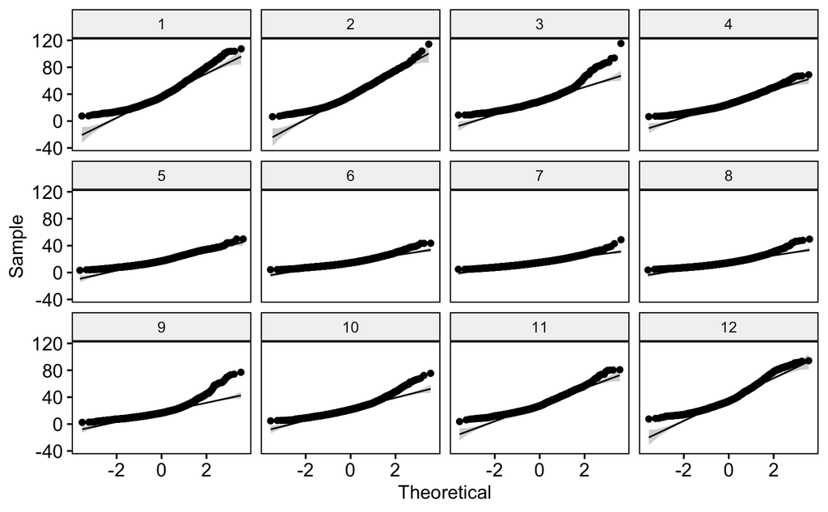

```r
ggqqplot(pm2_5.monthly , "pm2.5", facet.by = "month")
```

Data not in standard error range , It looks like non-normal distribution

### 2) Shapiro’s test

$H_0$ : Normal distribution in sample

[output not shown]

[output cut: 990 more lines]

**All non-normal distribution , comfirmed !!**

Thus, We have to use non-parametric alternative to the one-way ANOVA test, **Kruskal-Wallis Test.**

# Kruskal-Wallis Test

[Data Novia](https://www.datanovia.com/en/lessons/kruskal-wallis-test-in-r/)

$$H_0 : \mu_1 = \mu_2 = \mu_3 = \ ...\ = \mu_{12}$$
$$H_0 : \mu_1 \neq \mu_2 \neq \mu_3 \neq \ ...\ \neq \mu_{12}$$

|  | .y. | n | statistic | df | p | method |
| --- | --- | --- | --- | --- | --- | --- |
| 1 | pm2.5 | 34055 | 14987.95 | 11 | 0 | Kruskal-Wallis |

**P-value very close to 0 ?**

**Use Base R instead !**

```r
kruskal.test(pm2.5 ~ month, pm2_5.monthly)
```

```
    Kruskal-Wallis rank sum test

data:  pm2.5 by month
Kruskal-Wallis chi-squared = 14988, df = 11, p-value < 2.2e-16
```

**P-value is significant. Thus,there are at least one difference in mean pm2.5 between months.**  
**But, how much of the differences ?**

### Kruskal effectsize calculation

|  | .y. | n | effsize | method | magnitude |
| --- | --- | --- | --- | --- | --- |
| 1 | pm2.5 | 34055 | 0.4399422 | eta2[H] | large |

```r
pm2_5.monthly %>% rstatix::kruskal_effsize(pm2.5 ~ month)
```

**Meaning : 44% of variation in mean pm2.5 can be predicted by month. This effect size is large !!**

## Multiple pairwise-comparisons

From the output of the Kruskal-Wallis test, we know that there is a significant difference between groups, but we don’t know which pairs of groups are different.

### Dunn’s test

```r
dunn_pm2_5.month <- pm2_5.monthly %>%
        rstatix::dunn_test(pm2.5 ~ month, p.adjust.method = "bonferroni")
```

```r
dunn_pm2_5.month %>%
  mutate(mean_diff = if_else(p.adj > 0.001, "Non-Significant","Significant" )) %>%
  mutate(across(starts_with("g"),as_factor)) %>%
  select(".y.",starts_with("group"),p.adj,mean_diff) %>%
  arrange(desc(p.adj))
```

| .y. | group1 | group2 | p.adj | mean_diff |
| --- | --- | --- | --- | --- |
| pm2.5 | 1 | 2 | 1.000000e+00 | Non-Significant |
| pm2.5 | 1 | 12 | 1.000000e+00 | Non-Significant |
| pm2.5 | 2 | 12 | 1.000000e+00 | Non-Significant |
| pm2.5 | 5 | 9 | 1.000000e+00 | Non-Significant |
| pm2.5 | 6 | 7 | 1.000000e+00 | Non-Significant |
| pm2.5 | 6 | 8 | 1.000000e+00 | Non-Significant |
| pm2.5 | 7 | 8 | 1.000000e+00 | Non-Significant |
| pm2.5 | 3 | 11 | 4.807075e-07 | Significant |
| pm2.5 | 4 | 11 | 1.040260e-08 | Significant |
| pm2.5 | 3 | 12 | 1.545401e-19 | Significant |

[output cut: 56 more lines]

```r
NA
```

### Visualize significant Dunn’s test

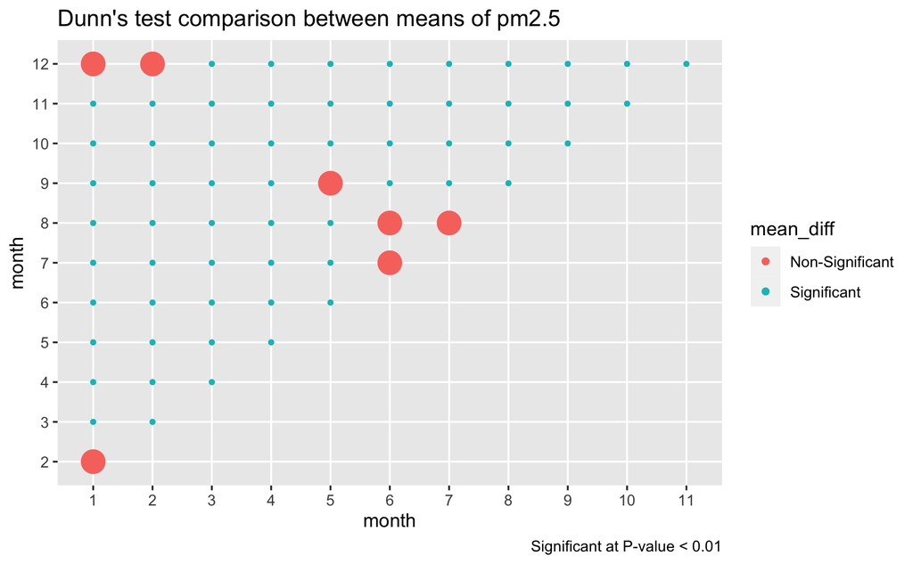

### Final Report

- There was a statistically significant differences of pm2.5 mean value between months as assessed using the Kruskal-Wallis test (p < 0.001). Pairwise Dunn’s test between months showed that all the difference between months was significant (Dunn’s test, p < 0.001) except for 7 pairs of months as indicated by red dot in above graph.

> Light Bridge : R-Studio 1.3.959 (mac)